# Shopping Trends

Marlen Gonzalez

2023-11-27

# Introduction

I’ve always been the consumer but never looked at shopping from the point of view from the business side of it. I don’t usually go to a store and wonder what the popular selling item is or what do people need the most of.

The dataset is from [Kaggle](https://www.kaggle.com/datasets/iamsouravbanerjee/customer-shopping-trends-dataset).

# Packages Used

```r
#using this to tidy and filter the data with dplyr
library(tidyverse)
#using this to draw plots
library(ggplot2)
```

# Data at a glimpse

```
## Rows: 3,900
## Columns: 19
## $ customer_id              <dbl> 1, 2, 3, 4, 5, 6, 7, 8, 9, 10, 11, 12, 13, 14…
## $ age                      <dbl> 55, 19, 50, 21, 45, 46, 63, 27, 26, 57, 53, 3…
## $ gender                   <chr> "Male", "Male", "Male", "Male", "Male", "Male…
## $ item_purchased           <chr> "Blouse", "Sweater", "Jeans", "Sandals", "Blo…
## $ category                 <chr> "Clothing", "Clothing", "Clothing", "Footwear…
## $ purchase_amount          <dbl> 53, 64, 73, 90, 49, 20, 85, 34, 97, 31, 34, 6…
## $ location                 <chr> "Kentucky", "Maine", "Massachusetts", "Rhode …
## $ size                     <chr> "L", "L", "S", "M", "M", "M", "M", "L", "L", …
## $ color                    <chr> "Gray", "Maroon", "Maroon", "Maroon", "Turquo…
## $ season                   <chr> "Winter", "Winter", "Spring", "Spring", "Spri…
## $ review_rating            <dbl> 3.1, 3.1, 3.1, 3.5, 2.7, 2.9, 3.2, 3.2, 2.6, …
## $ subscription_status      <chr> "Yes", "Yes", "Yes", "Yes", "Yes", "Yes", "Ye…
## $ payment_method           <chr> "Credit Card", "Bank Transfer", "Cash", "PayP…
## $ shipping_type            <chr> "Express", "Express", "Free Shipping", "Next …
## $ discount_applied         <chr> "Yes", "Yes", "Yes", "Yes", "Yes", "Yes", "Ye…
## $ promo_code_used          <chr> "Yes", "Yes", "Yes", "Yes", "Yes", "Yes", "Ye…
## $ previous_purchases       <dbl> 14, 2, 23, 49, 31, 14, 49, 19, 8, 4, 26, 10, …
## $ preferred_payment_method <chr> "Venmo", "Cash", "Credit Card", "PayPal", "Pa…
## $ frequency_of_purchases   <chr> "Fortnightly", "Fortnightly", "Weekly", "Week…
```

From just a glimpse we see a lot of columns of information.

# Key Terms

- customer_id
- age
- gender
- item_purchased
- category
- purchase_amount
- location
- size
- color
- season
- review_rating
- subscription_status
- payment_method
- shipping_type
- discount_applied
- promo_code_used
- previous_purchases
- preferred_payment_method
- frequency_of_purchases

# Questions

- How much are people spending? What are their ages?
- What gender is the main consumer?
- What sizes are in demand?
- What are they buying the most of, item and category?
- Is there a higher volume of sales in a specific state?
- Do consumers go for a specific color?
- What are buyers using as a way of payment?
- What are best/worst reviewed category?

# Items mainly bought:

```
## # A tibble: 25 × 2
##    item_purchased     n
##    <chr>          <int>
##  1 Blouse           171
##  2 Jewelry          171
##  3 Pants            171
##  4 Shirt            169
##  5 Dress            166
##  6 Sweater          164
##  7 Jacket           163
##  8 Belt             161
##  9 Coat             161
## 10 Sunglasses       161
## # ℹ 15 more rows
```

# Items least bought:

```
## # A tibble: 25 × 2
##    item_purchased     n
##    <chr>          <int>
##  1 Jeans            124
##  2 Gloves           140
##  3 Backpack         143
##  4 Boots            144
##  5 Sneakers         145
##  6 T-shirt          147
##  7 Shoes            150
##  8 Hoodie           151
##  9 Handbag          153
## 10 Hat              154
## # ℹ 15 more rows
```

# What is the average of what people are spending for their age?

```
## # A tibble: 53 × 2
##      age     n
##    <dbl> <int>
##  1    69    88
##  2    57    87
##  3    41    86
##  4    25    85
##  5    49    84
##  6    27    83
##  7    50    83
##  8    54    83
##  9    62    83
## 10    32    82
## # ℹ 43 more rows
```

```
## # A tibble: 53 × 2
##      age   avg
##    <dbl> <dbl>
##  1    53  67.9
##  2    49  66.1
##  3    44  64.9
##  4    28  64.6
##  5    61  64.2
##  6    21  64.1
##  7    51  63.9
##  8    65  63.8
##  9    54  63.6
## 10    25  63.2
## # ℹ 43 more rows
```

# What gender is the main consumer?

```
## # A tibble: 2 × 2
##   gender   avg
##   <chr>  <dbl>
## 1 Female  60.2
## 2 Male    59.5
```

# What sizes are in demand?

```
## # A tibble: 4 × 2
##   size      n
##   <chr> <int>
## 1 M      1755
## 2 L      1053
## 3 S       663
## 4 XL      429
```

# Is there a higher volume of sales in a specific state?

```
## # A tibble: 50 × 2
##    location       n
##    <chr>      <int>
##  1 Montana       96
##  2 California    95
##  3 Idaho         93
##  4 Illinois      92
##  5 Alabama       89
##  6 Minnesota     88
##  7 Nebraska      87
##  8 Nevada        87
##  9 New York      87
## 10 Delaware      86
## # ℹ 40 more rows
```

# continued (least)

```
## # A tibble: 50 × 2
##    location          n
##    <chr>         <int>
##  1 Kansas           63
##  2 Rhode Island     63
##  3 Arizona          65
##  4 Hawaii           65
##  5 New Jersey       67
##  6 Florida          68
##  7 Iowa             69
##  8 South Dakota     70
##  9 New Hampshire    71
## 10 Utah             71
## # ℹ 40 more rows
```

# Do consumers go for a specific color?

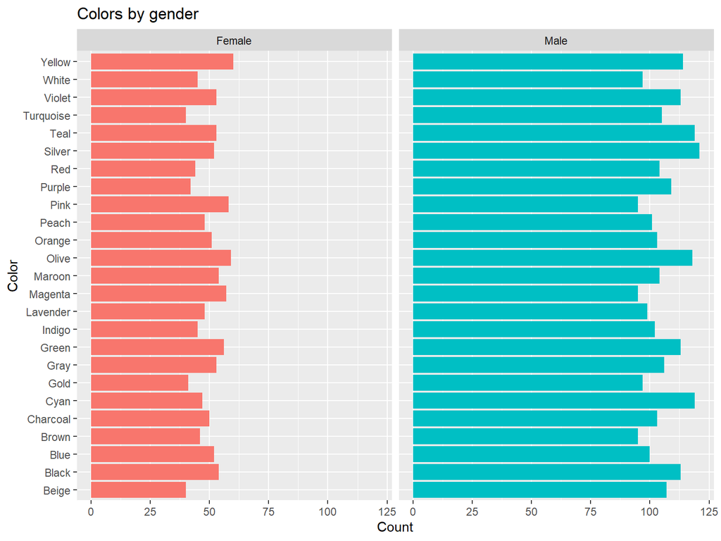

# What are they buying the most of?

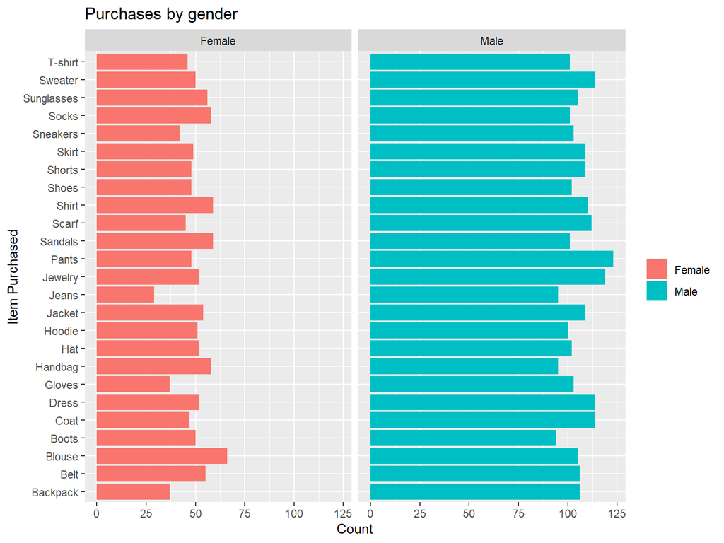

# Purchases by season

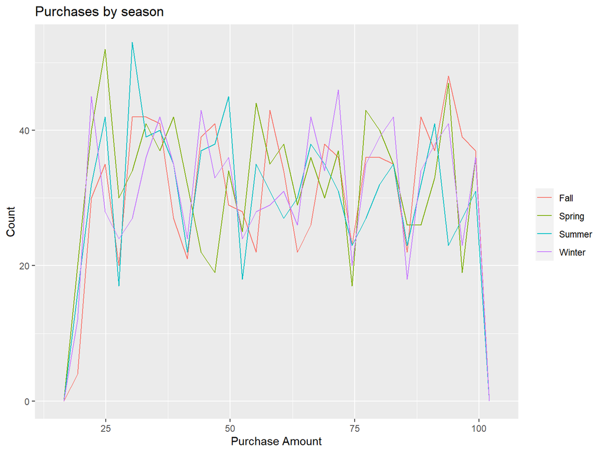

# Purchases by category

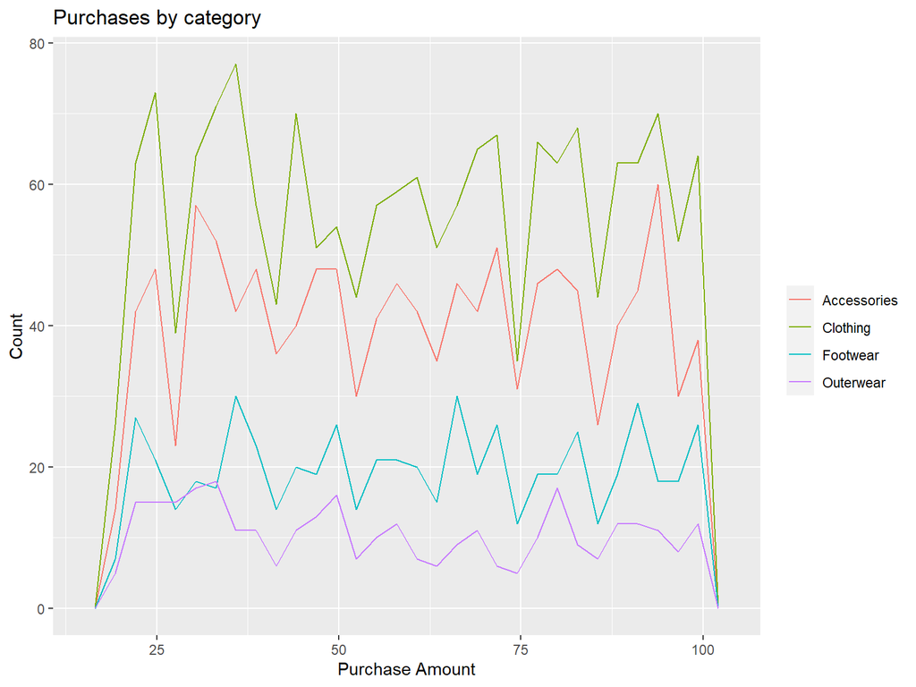

# What are buyers using as a way of payment?

[figure not shown]

# What categories have the best reviews?

[figure not shown]

# Summary

Understand your consumer.